# Auxiliar 02 - Aproximaciones discretas, para calcular normales en una malla

### CC5513 - Procesamiento Geométrico y Análisis de Formas

### Objetivo

En muchas ocasiones tenemos que calcular propiedades geométricas de las superficies. Cuando tenemos alguna representación analítica continua de esta, podemos obtener sus propiedades en cualquier punto con bastante exactitud, pero cuando tenemos mallas geométricas esto no es posible, pues sólo tenemos información discreta.

En estos casos, tenemos que encontrar aproximaciones o métodos discretos para calcular las propiedades, y en este auxiliar nos enfocaremos en uno de estos casos: comparar tres métodos para calcular las normales en los vértices de una malla.

## Contexto

En una malla triangular, sabemos que es relativamente directo calcular las normales de las caras. Las caras son triángulos, superficies planas representadas con 3 puntos. De estos tres puntos, es posible obtener dos vectores tangentes y pertenecientes al plano, y gracias a ello con un producto cruz obtener el vector perpendicular, la normal a la cara.

Pero nosotros queremos las normales de los vértices en vez de las caras, así que no es tan directo, tenemos queusar la información anterior.

Un vértice, sin embargo, puede pertenecer a varias caras cuyas normales podemos calcular, por lo que podemos obtener su normal 'ponerando' de alguna manera las de las caras. Así, en general, sabemos que la normal de un vértice se calcula como $$ n(v) = \frac{\sum_{T\in N_1(v)}\alpha_T n(T)}{||\sum_{T\in N_1(v)}\alpha_T n(T)||} $$

donde T son los triángulos adyacentes al vértice, $\alpha_T$ es un peso que pondera a cada triángulo y $n(T)$ es su normal. Nos centraremos en tres formas de elegir ese $\alpha_T$:

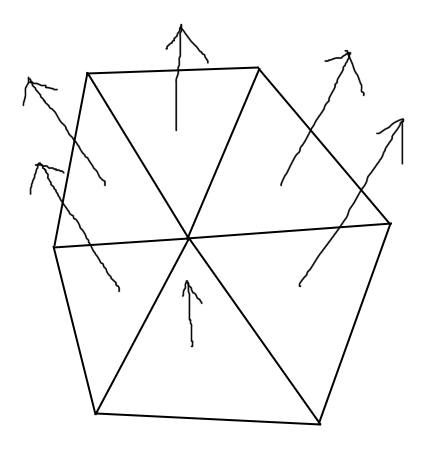

#### ¿Por qué no sólo promedio simple?

Las mallas triangulares no necesariamente tienen triángulos uniformes. Algunas veces hay triángulos mucho más grandes que otros, por lo que podría *'no ser justo'* que un vertice pondere de igual manera estas normales que podrían estar más lejanas. También la forma de los triángulos podría influir, pues podría ser que hayan triángulos tan '*delgados*' que sea poco lo que uno considere que aporten al vértice. Es por eso que surgen distintas formas de ponderar.

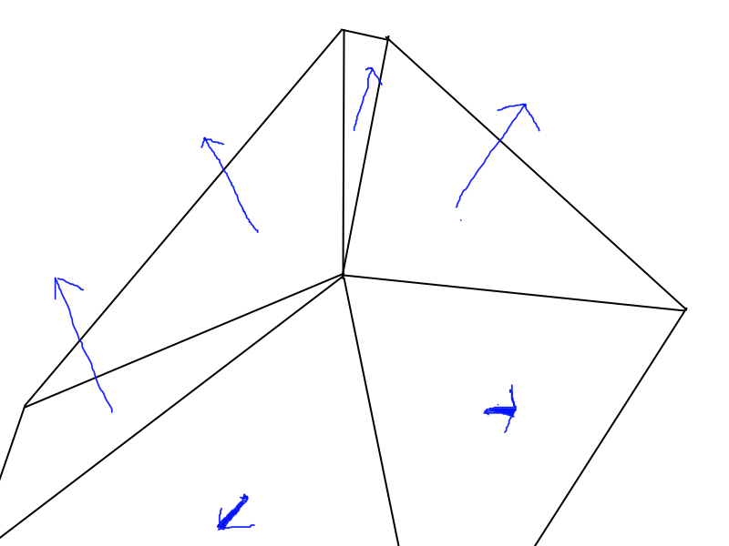

### ¿Qué haremos?

Necesitaremos comparar las normales de estos tres métodos con las normales teóricas. Como no es sencillo tener valores teóricos de una superficie cualquiera, utilizaremos la superficie de una esfera, pues sus normales son sencillas de calcular.

Tenemos tres archivos que representan la misma esfera pero con distinta cantidad de vértices:

- esfera1.off (482 vértices)
- esfera2.off (1986 vértices)
- esfera3.off (7938 vértices)

## Procedimiento

*Iremos guardando los códigos de este auxiliar en un archivo llamado script.py, que podemos ejecutar localmente en nuestras máquinas, y más adelante pueden subirlo junto a los archivos .off a collab para correr los experimentos*

#### Métrica de comparación

Si vamos a comparar los resultados, las normales de los distintos métodos, necesitamos ver cuánto se desvían de la normal teórica. Esto es una función que recibe una normal y devuelve su valor de error. Podemos hacerlo calculando el ángulo entre las normales.

$$cos(\theta) = \frac{\vec{u}\cdot\vec{v}}{||\vec{u}||\cdot||\vec{v}||}$$

$$\Rightarrow\quad\theta = \arccos\left(\frac{\vec{u}\cdot\vec{v}}{||\vec{u}||\cdot||\vec{v}||}\right)$$

```
def angle(u, v):
    """
    Calculate the angle between two vectors
    :param u:
    :param v:
    :return: the angle (radians)
    """
    du = np.linalg.norm(u)
    dv = np.linalg.norm(v)

    # avoid zeros in denominator
    du = max(du, 1e-8)
    dv = max(dv, 1e-8)

    return np.arccos(np.dot(u, v) / (du * dv))
```

### Cálculo de normales

#### Normales teóricas de una esfera centrada

Cuando una esfera de cualquier radio está centrada en el origen, la normal de cada punto de la superficie tiene la misma dirección que el vector que va desde el centro hacia el punto.

Nuestro vector normal a un punto P entonces corresponde a tomar el vector que apunta hacia el mismo punto, pero normalizado.

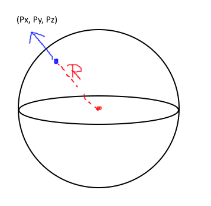

Nuestra función recibirá una malla esférica, y para cada vértice calculará su normal, devolviendo todas las normales de la malla.

```
def calculate_spherical_normals(mesh: openmesh.TriMesh):
    """
    Calculates the theoretical normal a sphere with center in (0, 0, 0) would have
    :param mesh:
    :return: array with normals
    """
    points = mesh.points()
    normal_vertices = np.zeros((mesh.n_vertices(), 3))

    for vertex in mesh.vertices():
        normal_vertices[vertex.idx()] = points[vertex.idx()] / np.linalg.norm(points[vertex.idx()])

    return normal_vertices
```

#### Normales por pesos constantes

Para nuestro caso donde simplemente promediamos las normales de las caras adyacentes, hemos de recorrer todas las caras de la malla. `openmesh` nos permite iterar sobre ellas utilizando `mesh.faces()`, por lo que el trabajo no será complicado. Primero calcularemos las normales de todas las caras, y luego para cada vértice podemos promediar.

```
def calculate_normals(mesh: openmesh.TriMesh):
    """
    Calculates the normals per vertex via adding the face normals.

    :param mesh:
    :return: array with normals
    """
    points = mesh.points()
    normal_faces = np.zeros((mesh.n_faces(), 3))

    for face in mesh.faces():
        v_it = openmesh.FaceVertexIter(mesh, face)

        v0 = next(v_it).idx()
        v1 = next(v_it).idx()
        v2 = next(v_it).idx()

        normal = np.cross(points[v1]-points[v0],
                          points[v2]-points[v0])
        normal /= np.linalg.norm(normal)
        normal_faces[face.idx()] = normal

    normal_vertices = np.zeros((mesh.n_vertices(), 3))
    for vertex in mesh.vertices():
        face_it = openmesh.VertexFaceIter(mesh, vertex)
        for face in face_it:
            normal_vertices[vertex.idx(), :] += normal_faces[face.idx(), :]

        normal_vertices[vertex.idx(), :] /= np.linalg.norm(normal_vertices[vertex.idx(), :])

    return normal_vertices
```

#### Normales por pesos de área

Al momento de calcular la normal de cada cara, aprovecharemos de calcular también su área. Como son triángulos, basta obtener el módulo del producto cruz entre dos vectores que los forman, y dividir en dos para convertir ese área del paralelogramo en el área del triángulo.

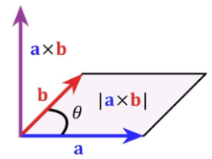

Como la normal se calcula con el mismo producto cruz, podemos aprovechar ese resultado intermedio.

Una vez hecho esto, podemos ponderar recorriendo cada vértice.

```
def calculate_normals_weighting_areas(mesh: openmesh.TriMesh):
    """
    Calculates the normals per vertex via weighting the face normals by area
    :param mesh:
    :return: array with normals
    """
    points = mesh.points()
    normal_faces = np.zeros((mesh.n_faces(), 3))
    face_surfaces = np.zeros(mesh.n_faces())

    for face in mesh.faces():
        v_it = openmesh.FaceVertexIter(mesh, face)

        v0 = next(v_it).idx()
        v1 = next(v_it).idx()
        v2 = next(v_it).idx()

        normal = np.cross(points[v1] - points[v0],
                          points[v2] - points[v0])
        face_surfaces[face.idx()] = np.linalg.norm(normal) / 2  # triangle area = 1/2 cross product of two sides
        normal /= np.linalg.norm(normal)
        normal_faces[face.idx()] = normal

    normal_vertices = np.zeros((mesh.n_vertices(), 3))
    for vertex in mesh.vertices():
        face_it = openmesh.VertexFaceIter(mesh, vertex)
        for face in face_it:
            normal_vertices[vertex.idx(), :] += face_surfaces[face.idx()] * normal_faces[face.idx(), :]

        normal_vertices[vertex.idx(), :] /= np.linalg.norm(normal_vertices[vertex.idx(), :])

    return normal_vertices
```

#### Normales por pesos angulares

Análogo a los anteriores, debemos recorrer las caras calculando las normales y esta vez los ángulos, y luego para cada vértice utilizar esta información y ponderar. Dado que las caras tienen 3 ángulos en vez de un solo valor, utilizaremos un diccionario que asocia cada vértice con su ángulo.

Para calcular los ángulos nos colgaremos de la función que hicimos al inicio, que dados dos vectores devolvía el ángulo entre ellos.

```
def calculate_normals_weighting_angles(mesh: openmesh.TriMesh):
    """
    Calculates the normals per vertex via weighting the face normals by the angles they make at each vertex
    :param mesh:
    :return: array with normals
    """
    points = mesh.points()
    normal_faces = np.zeros((mesh.n_faces(), 3))
    face_angles = np.zeros(mesh.n_faces(), dtype=dict)

    for face in mesh.faces():
        v_it = openmesh.FaceVertexIter(mesh, face)

        v0 = next(v_it).idx()
        v1 = next(v_it).idx()
        v2 = next(v_it).idx()

        normal = np.cross(points[v1] - points[v0],
                          points[v2] - points[v0])
        normal /= np.linalg.norm(normal)
        normal_faces[face.idx()] = normal

        # store the three angles of the triangular face
        face_angles[face.idx()] = {
            v0: angle(points[v1] - points[v0], points[v2] - points[v0]),
            v1: angle(points[v2] - points[v1], points[v0] - points[v1]),
            v2: angle(points[v0] - points[v2], points[v1] - points[v2])
        }

    normal_vertices = np.zeros((mesh.n_vertices(), 3))
    for vertex in mesh.vertices():
        face_it = openmesh.VertexFaceIter(mesh, vertex)
        for face in face_it:
            # face_angles[face.idx()] has the three angles of the current face
            # and with that, we can look for the vertex of the face we are on
            normal_vertices[vertex.idx(), :] += face_angles[face.idx()][vertex.idx()] * normal_faces[face.idx(), :]

        normal_vertices[vertex.idx(), :] /= np.linalg.norm(normal_vertices[vertex.idx(), :])

    return normal_vertices
```

## Resultados

Con el siguiente código, utilizando polyscope podemos visualizar las cuatro normales de la esfera. Utilizaremos el argumento `--file` para elegir el archivo con la esfera.

```
parser = argparse.ArgumentParser()
parser.add_argument("--file", type=str, required=True,
                    help="Name of the file you want to calculate its vertex normals")
opt = parser.parse_args()
fmesh = openmesh.read_trimesh(opt.file)

ps.init()
ps_mesh = ps.register_surface_mesh("mesh", fmesh.points(), fmesh.face_vertex_indices())
ps_mesh.add_vector_quantity("normals", calculate_spherical_normals(fmesh))
ps_mesh.add_vector_quantity("normals (Avg of face normals)",
                            calculate_normals(fmesh))
ps_mesh.add_vector_quantity("normals (surface ponderation of face normals)",
                            calculate_normals_weighting_areas(fmesh))
ps_mesh.add_vector_quantity("normals (angle ponderation of face normals)",
                            calculate_normals_weighting_angles(fmesh))
ps.show()
```

#### Recolección de Datos

Como se tienen tres esferas ".off" para procesar, para cada una de ellas se seguirá el siguiente procedimiento:

- Cargar la malla triangular a partir del archivo.
- En una tabla, para cada vértice:
  - se guardan sus coordenadas en tres columnas separadas
  - se calcula su normal teórica para una esfera: $\frac{v}{||v||}$, y se añaden las tres coordenadas a la tabla.
  - se calcula su normal con el método de pesos constantes, y estas tres coordenadas se insertan en 3 nuevas columnas.
  - se calcula su normal con el método de pesos de área
  - se calcula su normal con el método de pesos de ángulo

Con ello, se obtendrán tres tablas (DataFrames de Pandas) en el que se encuentran los datos necesarios para comparar los métodos.

```python
# IMPORTANTE: Las funciones que hicimos anteriormente las colocamos en un archivo llamado script.py
# Para correr las siguientes celdas del notebook, deben subir a su entorno este archivo,
# junto a los archivos esfera1.off, esfera2.off y esfera3.off.

!pip install openmesh
!pip install polyscope

import script  # where we wrote all of our functions
import numpy as np
import pandas as pd
import openmesh
from matplotlib import pyplot as plt
```

```python
# diccionario con las tres mallas de triángulos
meshes = {
    "esfera1": openmesh.read_trimesh("esfera1.off"),
    "esfera2": openmesh.read_trimesh("esfera2.off"),
    "esfera3": openmesh.read_trimesh("esfera3.off")
}

# preparamos espacio para guardar los dataframes con los cálculos
dfs = {}

for key in meshes:

    # el Dataframe guardará las coordenadas de sus vértices,
    # así como las coordenadas de las 3 normales que son calculadas con distintos métodos

    # coordenadas de los vértices
    table = {
        "vx": meshes[key].points()[:, 0],
        "vy": meshes[key].points()[:, 1],
        "vz": meshes[key].points()[:, 2]
    }

    # coordenadas de las normales teóricas en esos vértices para una esfera
    normals = script.calculate_spherical_normals(meshes[key])
    table["nx"] = normals[:, 0]
    table["ny"] = normals[:, 1]
    table["nz"] = normals[:, 2]


    # coordenadas de las normales al vértice, calculadas sumando las normales de las caras adyacentes
    normals = script.calculate_normals(meshes[key])
    table["n_1_x"] = normals[:, 0]
    table["n_1_y"] = normals[:, 1]
    table["n_1_z"] = normals[:, 2]

    # coordenadas de las normales al vértice, calculadas ponderando las normales de las caras adyacentes según sus áreas
    normals = script.calculate_normals_weighting_areas(meshes[key])
    table["n_area_x"] = normals[:, 0]
    table["n_area_y"] = normals[:, 1]
    table["n_area_z"] = normals[:, 2]

    # coordenadas de las normales al vértice, calculadas ponderando las normales de las caras adyacentes según el ángulo que le significan
    normals = script.calculate_normals_weighting_angles(meshes[key])
    table["n_angle_x"] = normals[:, 0]
    table["n_angle_y"] = normals[:, 1]
    table["n_angle_z"] = normals[:, 2]

    # Finalmente guardamos esta tabla en nuestro diccionario de tablas

    dfs[key] = pd.DataFrame(data=table)
```

```python
# Resultados para esfera1.off
dfs["esfera1"].head()
```

|  | vx | vy | vz | nx | ny | nz | n_1_x | n_1_y | n_1_z | n_area_x | n_area_y | n_area_z | n_angle_x | n_angle_y | n_angle_z |
| --- | --- | --- | --- | --- | --- | --- | --- | --- | --- | --- | --- | --- | --- | --- | --- |
| 0 | 0.0 | 0.980785 | -0.195090 | 0.0 | 0.980785 | -0.195090 | -5.808935e-19 | 0.973860 | -0.227151 | 0.000000e+00 | 0.970119 | -0.242631 | 0.000000e+00 | 0.979598 | -0.200967 |
| 1 | 0.0 | 0.923880 | -0.382683 | 0.0 | 0.923880 | -0.382683 | -1.162446e-18 | 0.910838 | -0.412765 | 0.000000e+00 | 0.907250 | -0.420593 | 0.000000e+00 | 0.921708 | -0.387885 |
| 2 | 0.0 | 0.831470 | -0.555570 | 0.0 | 0.831470 | -0.555570 | 1.163381e-18 | 0.812814 | -0.582523 | 0.000000e+00 | 0.809596 | -0.586987 | 0.000000e+00 | 0.828645 | -0.559775 |
| 3 | 0.0 | 0.707107 | -0.707107 | 0.0 | 0.707107 | -0.707107 | 0.000000e+00 | 0.683553 | -0.729901 | 0.000000e+00 | 0.680868 | -0.732406 | 0.000000e+00 | 0.704059 | -0.710142 |
| 4 | 0.0 | 0.555570 | -0.831470 | 0.0 | 0.555570 | -0.831470 | 0.000000e+00 | 0.528020 | -0.849232 | -2.201067e-18 | 0.525996 | -0.850487 | -2.238216e-18 | 0.552760 | -0.833340 |

```python
# Resultados para esfera2.off
dfs["esfera2"].head()
```

|  | vx | vy | vz | nx | ny | nz | n_1_x | n_1_y | n_1_z | n_area_x | n_area_y | n_area_z | n_angle_x | n_angle_y | n_angle_z |
| --- | --- | --- | --- | --- | --- | --- | --- | --- | --- | --- | --- | --- | --- | --- | --- |
| 0 | 0.0 | 0.973792 | -0.199755 | 0.0 | 0.979602 | -0.200947 | -7.238015e-20 | 0.980159 | -0.198211 | 0.000000e+00 | 0.978469 | -0.206393 | -3.454008e-20 | 0.976970 | -0.213378 |
| 1 | 0.0 | 0.917962 | -0.377797 | 0.0 | 0.924745 | -0.380588 | 4.342579e-19 | 0.922514 | -0.385964 | 0.000000e+00 | 0.920205 | -0.391437 | -5.532366e-19 | 0.921943 | -0.387325 |
| 2 | 0.0 | 0.826144 | -0.548476 | 0.0 | 0.833113 | -0.553103 | 0.000000e+00 | 0.820544 | -0.571583 | 0.000000e+00 | 0.819687 | -0.572812 | 0.000000e+00 | 0.829109 | -0.559087 |
| 3 | 0.0 | 0.702578 | -0.698078 | 0.0 | 0.709375 | -0.704831 | 0.000000e+00 | 0.693127 | -0.720816 | -6.594452e-19 | 0.692403 | -0.721511 | 0.000000e+00 | 0.704078 | -0.710123 |
| 4 | 0.0 | 0.552012 | -0.820853 | 0.0 | 0.558039 | -0.829815 | 0.000000e+00 | 0.539426 | -0.842033 | 0.000000e+00 | 0.538867 | -0.842391 | 0.000000e+00 | 0.552411 | -0.833572 |

```python
# Resultados para esfera3.off
dfs["esfera3"].head()
```

|  | vx | vy | vz | nx | ny | nz | n_1_x | n_1_y | n_1_z | n_area_x | n_area_y | n_area_z | n_angle_x | n_angle_y | n_angle_z |
| --- | --- | --- | --- | --- | --- | --- | --- | --- | --- | --- | --- | --- | --- | --- | --- |
| 0 | 0.0 | 0.973792 | -0.199755 | 0.0 | 0.979602 | -0.200947 | 0.000000e+00 | 0.979450 | -0.201687 | 0.000000 | 0.979084 | -0.203457 | -1.380717e-19 | 0.977955 | -0.208818 |
| 1 | 0.0 | 0.917962 | -0.377797 | 0.0 | 0.924745 | -0.380588 | -1.275961e-07 | 0.922879 | -0.385090 | 0.000000 | 0.922310 | -0.386451 | -1.958884e-07 | 0.922738 | -0.385428 |
| 2 | 0.0 | 0.826144 | -0.548476 | 0.0 | 0.833113 | -0.553103 | -4.831762e-06 | 0.825204 | -0.564835 | -0.000005 | 0.824983 | -0.565157 | -2.526738e-06 | 0.829639 | -0.558300 |
| 3 | 0.0 | 0.702578 | -0.698078 | 0.0 | 0.709375 | -0.704831 | 0.000000e+00 | 0.698992 | -0.715129 | 0.000000 | 0.698805 | -0.715312 | 0.000000e+00 | 0.704639 | -0.709566 |
| 4 | 0.0 | 0.552012 | -0.820853 | 0.0 | 0.558039 | -0.829815 | -3.478291e-06 | 0.546273 | -0.837607 | -0.000004 | 0.546128 | -0.837702 | -2.372287e-06 | 0.552930 | -0.833228 |

#### Obtención de errores

La medida $\varepsilon(n_c(v)) = \arccos(n_c(v)\cdot n_r(v))$ nos indica el error de una normal calculada en un vértice ($n_r(v))$ respecto a la teórica ($n_c(v)$), pues indica el ángulo entre estos dos vectores. A continuación, calculamos el promedio de este error obtenido para el total de los vértices según cada método.

```python
res = {"Método de Pesos": ["Constantes", "Areas", "Angulos"]}
for key in dfs:
    df = dfs[key]

    res["Error medio "+key+" [grados]"] = np.rad2deg([
        np.mean(np.arccos(df["nx"] * df["n_1_x"] + df["ny"] * df["n_1_y"] + df["nz"] * df["n_1_z"])),  # constantes
        np.mean(np.arccos(df["nx"] * df["n_area_x"] + df["ny"] * df["n_area_y"] + df["nz"] * df["n_area_z"])),  # area
        np.mean(np.arccos(df["nx"] * df["n_angle_x"] + df["ny"] * df["n_angle_y"] + df["nz"] * df["n_angle_z"])),  # angulos
        ])

df_errores = pd.DataFrame(res)
df_errores.set_index("Método de Pesos")
```

| Método de Pesos | Error medio esfera1 [grados] | Error medio esfera2 [grados] | Error medio esfera3 [grados] |
| --- | --- | --- | --- |
| Constantes | 0.990630 | 0.834288 | 0.423791 |
| Areas | 1.203871 | 0.889461 | 0.442237 |
| Angulos | 0.212137 | 0.393649 | 0.346205 |

```python
df_T = df_errores.T
df_T.columns = df_T.iloc[0]
df_T = df_T[1:]
df_T
```

| Método de Pesos | Constantes | Areas | Angulos |
| --- | --- | --- | --- |
| Error medio esfera1 [grados] | 0.99063 | 1.203871 | 0.212137 |
| Error medio esfera2 [grados] | 0.834288 | 0.889461 | 0.393649 |
| Error medio esfera3 [grados] | 0.423791 | 0.442237 | 0.346205 |

### Visualización de Resultados

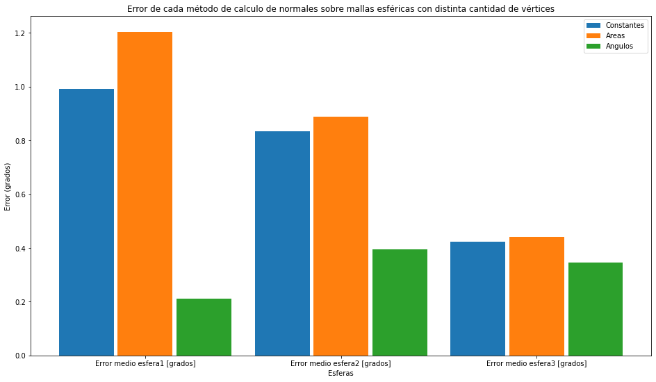

```python
X_axis = np.arange(len(df_T.index))

plt.rcParams["figure.figsize"] = (16,9)
plt.bar(X_axis - 0.3, df_T["Constantes"], 0.28, label = 'Constantes')
plt.bar(X_axis + 0.0, df_T["Areas"], 0.28, label = 'Areas')
plt.bar(X_axis + 0.3, df_T["Angulos"], 0.28, label = 'Angulos')


plt.xticks(X_axis, df_T.index)
plt.xlabel("Esferas")
plt.ylabel("Error (grados)")
plt.title("Error de cada método de calculo de normales sobre mallas esféricas con distinta cantidad de vértices")
plt.legend()
plt.show()
```

Sería interesando poder correr este código con superficies más complejas y con triángulos no tan uniformes como el caso de la esfera, pero aún así pueden apreciar grandes diferencies entre los métodos, especialmente cuando hay pocos vértices.

El método de ponderación por ángulos aunque es más caro de calcular y puede ser ligeramente más lento, puede considerarse un buen trade-off dada su precisión incluso en otras mallas, pero uno puede elegir caso a caso dependiendo de sus necesidades.